# Valoração de Ativos de PI · Métodos e Aplicações

Propriedade Intelectual e Inovação · Tema 06

Prof. Dr. Luiz Diego Vidal Santos

# Introdução

[figure not shown]

## Ativos Intangíveis: Definição e Relevância

### Conceito Fundamental

**Ativos Intangíveis** (Lev, 2001) - Recursos sem substância física - Geram valor econômico futuro - Crescente participação no valor de mercado

**Setores Tecnológicos**: >80% da capitalização de mercado

### Composição

**Capital Humano** - Conhecimento - Competências - Expertise

### Tipologia

**Capital Estrutural** - Processos - Sistemas - Cultura organizacional

**Capital Relacional** - Redes - Reputação - Marca

**Propriedade Intelectual**: Subconjunto crítico com proteção jurídica

## Propriedade Intelectual no Brasil

### Estrutura Normativa

**Propriedade Industrial** (Lei 9.279/1996) - Patentes - Marcas - Desenhos industriais

**Direitos Autorais** (Lei 9.610/1998) - Obras literárias e artísticas - Proteção automática

**Programas de Computador** (Lei 9.609/1998) - Software - Código-fonte

### Outras Proteções

**Cultivares** (Lei 9.456/1997) - Variedades vegetais

**Informações Confidenciais** - *Know-how* - Segredo industrial

**Base Internacional**: Convenção de Berna, TRIPS

**Objetivo**: Equilibrar proteção exclusiva com acesso social ao conhecimento

## PI como Competência Estratégica

### Além do Ritual Contábil

**Valoração de PI é Competência Estratégica que:** - Orienta investimentos em P&D - Desenha estratégias de comercialização - Viabiliza captura de valor da inovação

### Marco Legal de CT&I (Lei 13.243/2016)

**Núcleos de Inovação Tecnológica (NITs)** - Gestão de ativos intangíveis - Negociação e comercialização - Domínio metodológico rigoroso

**Definição**

“Medir, com rigor analítico, a **promessa econômica** de ideias juridicamente protegidas”

**Desafio**: Transformar conhecimento protegido em valor capturável

# Métodos de Valoração

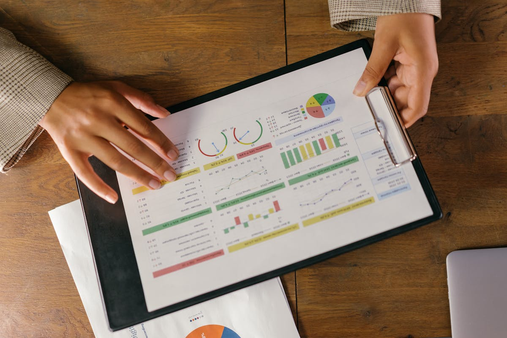

## Abordagens Tradicionais (Smith & Parr, 2000)

### Três Pilares Metodológicos

**1. Abordagem de Custo**

**Base**: Custo histórico ou de reposição

**Vantagem** - Estabelece piso de valor - Dados objetivos

**Limitação** - Dissocia-se do potencial de mercado - Ignora valor futuro

**2. Abordagem de Mercado**

**Base**: Transações comparáveis

**Vantagem** - Reflete dinâmica real

**Limitação** - Unicidade dos ativos de PI - Confidencialidade de acordos - Difícil comparabilidade

**3. Abordagem de Renda**

**Base**: Benefícios econômicos futuros

**Técnicas** - Fluxo de Caixa Descontado (FCD) - *Relief from Royalty*

**Status**: **Mais robusta**

## Estrutura de Mercado e Adequação Metodológica

### Framework de Arora et al. (2001)

**Mercados “Espessos” (*Thick Markets*)**

**Características** - Muitas transações - Alta liquidez - Dados comparáveis disponíveis

**Método Adequado** - ✅ Abordagem de Mercado - Comparação viável - Benchmarking robusto

**Mercados “Finos” (*Thin Markets*)**

**Características** - Poucas transações - Tecnologias emergentes - Alta unicidade

**Métodos Adequados** - ✅ Abordagem de Renda - ✅ Opções Reais - Modelagem de incerteza

**Conclusão**: Eficácia do método depende da **estrutura de mercado**

## Valoração e Precificação em Transferência de Tecnologia

**Valoração**

**Função** - Estimar faixa de valor esperado sob incerteza - Explicitar premissas econômicas e riscos - Estruturar fluxos econômicos do ativo

**Ênfase** - Consistência do modelo - Auditabilidade das hipóteses

**Precificação**

**Função** - Produzir preço de transação aceitável às partes - Calibrar valorações independentes na negociação - Internalizar custos complementares do licenciado

**Implicação prática** - O custo total de adoção inclui adaptação, conformidade, integração e comercialização

**Síntese**: Precificar exige conectar o modelo a uma métrica monetizável e verificável (Embrapa, 2022)

## Royalties como Âncora de Negociação (Embrapa, 2022)

**Faixas setoriais e limitações**

**Sinal de mercado** - Em Governo e Universidade há concentração em 2% a 5% e 5% a 10% - No setor farmacêutico a concentração tende a 5% a 10%

**Restrição** - Comparáveis são imperfeitos e os acordos são heterogêneos

**Efeito da maturidade tecnológica**

**Médias de royalties por estágio** - Pré-clínico 4,3% - Pré-POC 4,6% - Já comercializados 11,6%

**Medianas** - 3,5%, 5,0% e 7,5%

**Leitura** - Quanto mais inicial o estágio, menor a taxa negociada por maior risco

## Taxa de Desconto e Sensibilidade do FCD (Embrapa, 2022)

**Determinantes**

**Três componentes recorrentes** - Inflação como piso intertemporal - Custo de oportunidade em alternativas de investimento - Prêmio de risco associado à incerteza de retorno

**Critério operacional**

**Alinhamento ao retorno exigido** - Uso do custo de capital na estrutura de capital - CMPC como referência para remunerar capital próprio e de terceiros

**Ponto crítico** - Pequenas variações na taxa alteram substancialmente o VPL

## Limitações das Abordagens Tradicionais

### Desafios em Mercados Tecnológicos

**Alta Incerteza** - Trajetórias tecnológicas imprevisíveis - Adoção de mercado incerta - Cenários múltiplos

**Natureza Dinâmica** - Ciclos de vida curtos - Obsolescência rápida - Competição intensa

**Complexidade** - Múltiplas dimensões de valor - Interdependências tecnológicas - Efeitos de rede

**Insuficiências Metodológicas**

**FCD Tradicional** - Estimativa pontual - Assume certeza - Ignora flexibilidade gerencial

**Comparação de Mercado** - Dados escassos - Ativos não fungíveis - Contextos específicos

**Necessidade**: Métodos que capturem incerteza, não-linearidade e dinamismo

## Evolução: Métodos Computacionais e ML

### Zhou & Wang (2022)

**Integração de ML com Modelos Paramétricos**

**Algoritmos** - *Random Forests* - *Gradient Boosting* - Redes Neurais

**Capacidades** - Processar grandes volumes de dados patentários - Revelar padrões não lineares - Capturar relações complexas

Superação de limites dos métodos tradicionais

### Wu & Li (2022)

**Modelo de Contribuição Tecnológica**

**Métricas Quantitativas** - Desempenho técnico - Parâmetros objetivos

**Métricas Qualitativas** - Valor estratégico - Risco comercial - Potencial disruptivo

**Resultado**: Análise multidimensional e contextual

## Deslocamento Paradigmático na Valoração

### Abordagem Tradicional

**Características** - Estimativa estática - Valor pontual - Métodos isolados - Dados limitados

**Limitações** - Não captura complexidade - Ignora dinamismo - Subestima incerteza

⬇️ **EVOLUÇÃO** ⬇️

### Abordagem Contemporânea

**Características** - Análise dinâmica - Distribuição probabilística - Integração de métodos - Big data + ML

**Ganhos** - Complexidade multidimensional - Adaptação contextual - Gestão de incerteza

**Decisão Estratégica**: Método contingente, setorial e situacional

# Estratégias de Comercialização

[figure not shown]

## Transferência Tecnológica (Bozeman, 2000)

### Modelos de Comercialização

**Licenciamento**

**Exclusivo** - Um único licenciado - Direitos exclusivos - Maior royalty

**Não Exclusivo** - Múltiplos licenciados - Ampla disseminação - Menor royalty unitário

**Joint Ventures**

**Características** - Parceria estratégica - Compartilhamento de riscos - Investimento conjunto - Governança colaborativa

**Aplicação** - Projetos de longo prazo - Alta complexidade

**Spin-offs Acadêmicas**

**Características** - Nova empresa - Tecnologia da instituição - Empreendedorismo

**Vantagens** - Controle da aplicação - Upside ilimitado - Ecossistema de inovação

**Questão Central**: Como escolher o modelo adequado?

## Precificação em Licenciamento (Embrapa, 2022)

**Estrutura de pagamento**

**Componentes usuais** - Pagamento inicial (*upfront*) - *Royalties* correntes sobre base definida - Pagamento mínimo para reduzir risco de subexploração - *Milestones* para marcos de desenvolvimento e mercado

**Ponto de controle** - Definir base de incidência e métrica auditável de apuração

**Calibração por risco e maturidade**

**Evidência por estágio** - Média pré-clínico 4,3% - Média pré-POC 4,6% - Média já comercializados 11,6%

**Medianas** - 3,5%, 5,0% e 7,5%

**Leitura** - Estruturas escalonadas reduzem divergência de expectativas na negociação

## Regimes de Apropriabilidade (Teece, 1986)

### Teoria Fundamental

**Lucro com Inovação depende de:**

**1. Regime de Apropriabilidade** - Força da proteção de PI - Barreiras à imitação - Efetividade dos direitos exclusivos

**2. Controle de Ativos Complementares** - Manufatura - Distribuição - Marca - Serviços pós-venda

**Regimes “Fortes”**

**Exemplo**: Farmacêutico - Patentes robustas - Alta barreira à imitação - Proteção efetiva

**Estratégia Viável** - Licenciamento - Exploração direta

**Regimes “Fracos”**

**Exemplo**: Software - Replicação fácil - Baixa barreira técnica

**Resposta Necessária** - Controle de ativos complementares - Integração vertical

## Ativos Complementares: Caso Crítico

### Cenário: Startup com Patente Robusta

**Situação** - Tecnologia inovadora protegida - Patente de alta qualidade - **MAS**: Sem ativos complementares

**Ausências Críticas** - Canais de distribuição - Reconhecimento de marca - Capacidade produtiva - Força de vendas

**Dilema Estratégico** - Exploração direta: Alto risco, alta recompensa - Licenciamento: Risco mitigado, retorno compartilhado

**Dinâmica de Poder**

**Empresa Estabelecida** - Canais consolidados - Marca reconhecida - Escala de produção - Posição negocial forte

⬇️

**Resultado Provável** - Startup licencia tecnologia - Empresa captura maior parte do valor - Startup recebe royalties

**Lição**: Proteção legal ≠ Captura de valor

## Marcas como Estratégia de PI

### Papel Estratégico das Marcas

**Mecanismos de Apropriação** - Simbólicos: Identidade, valores - Relacionais: Confiança, reputação

**Funções** - Ampliar diferencial competitivo - Reduzir vulnerabilidade em regimes fracos - Extensão da estratégia de PI

**Branding**: Traduz valor técnico em percepção de valor

### Sinergia de Proteção

**Proteção Formal** - Patentes - Registros - Direitos exclusivos legais

**Proteção Simbólica** - Marcas - Reputação - Capital relacional

**Resultado**: Fortalecimento do ciclo de inovação, monetização e fidelização

## Framework de Decisão (Bradley et al., 2013)

### Quatro Fatores Críticos para Escolha Estratégica

**1. Maturidade Tecnológica (TRL)**

*Technology Readiness Level* - TRL 1-3: Pesquisa básica - TRL 4-6: Prototipagem - TRL 7-9: Prontidão para mercado

**Impacto na Estratégia** - Baixo TRL → Parceria de desenvolvimento - Alto TRL → Licenciamento ou spin-off

**2. Análise de Mercado**

**Dimensões** - Demanda atual e potencial - Concorrência e substitutos - Barreiras de entrada - Janela de oportunidade

**3. Estratégia de PI**

**Definições** - Escopo da proteção - Abrangência geográfica - Duração e manutenção - Portfolio de ativos

**4. Capacidades Organizacionais**

**Do Detentor** - Recursos internos - Expertise de mercado

**Do Parceiro/Licenciado** - **Capacidade Absortiva** (Cohen & Levinthal, 1990) - Habilidade de assimilar e aplicar conhecimento externo

## Capacidade Absortiva: Fator Determinante

### Cohen & Levinthal (1990)

**Definição** Habilidade organizacional de: - Reconhecer o valor de informação externa - Assimilar conhecimento novo - Aplicar comercialmente

**Características** - Cumulativa (*path-dependent*) - Baseada em conhecimento prévio - Requer investimento contínuo

### Implicação para Licenciamento

**Cenário de Sucesso** - Licenciado com alta capacidade absortiva - Compreende e aplica tecnologia - Extrai valor efetivamente - Parceria frutífera

**Cenário de Fracasso** - Licenciado sem capacidade absortiva - Não consegue implementar - Valor não realizado - Parceria infrutífera

**Conclusão**: Avaliar capacidade absortiva do parceiro é essencial

# NITs e Arsenal Analítico

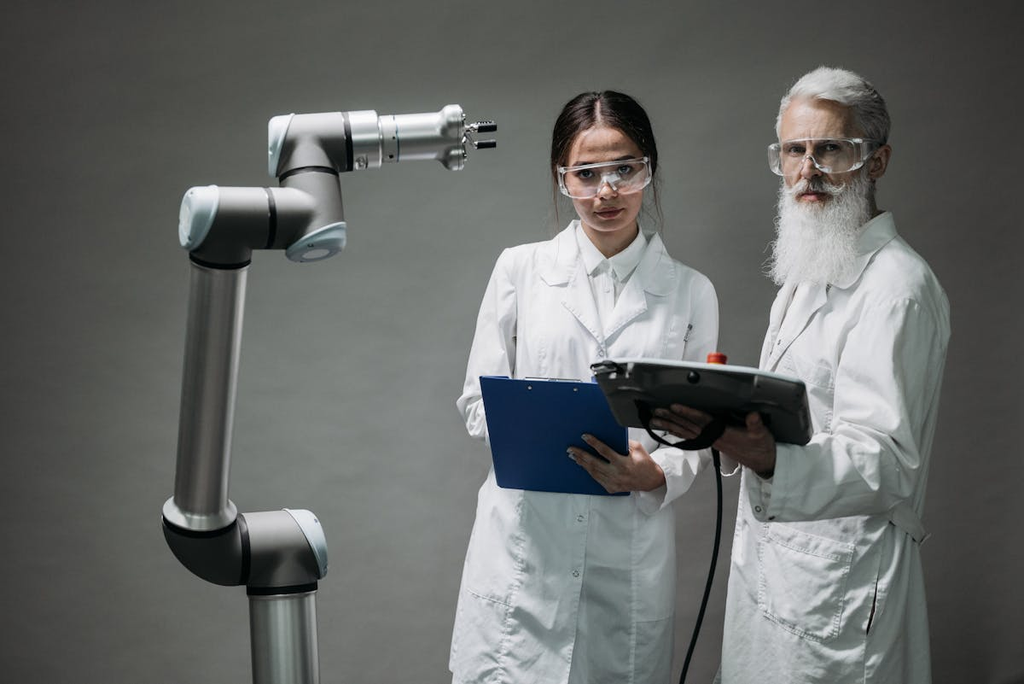

## NITs no Marco Legal de CT&I

### Lei 13.243/2016 e Decreto 9.283/2018

**Fortalecimento dos NITs** - Ampliação de competências - Autonomia de gestão - Papel estratégico

**Função Central** - Mediadores estratégicos - Navegação da complexidade - Ponte entre academia e mercado

NITs como agentes de inovação

### Competências Essenciais

**Técnicas** - Metodologias de valoração - Análise de mercado - Gestão de PI

**Relacionais** - Articulação de ecossistema - Negociação - Mediação de interesses

**Objetivo**: Maximizar retorno social e econômico do conhecimento

## Inteligência Competitiva: Ponto de Partida

### Buscas de Anterioridade

**Finalidade** - Verificar novidade - Identificar arte anterior - Avaliar patenteabilidade

**Bases de Dados** - USPTO, EPO, WIPO - INPI (Brasil) - Patentscope

**Resultado** - Validação técnica - Estratégia de reivindicações

### Análise de Paisagem Patentária

**Componentes** - Mapeamento de concorrentes - Identificação de tendências - Análise de citações - Famílias de patentes

**Inteligência Fornecida** - Estado da arte tecnológico - Posicionamento competitivo - Espaços de liberdade (*white spaces*)

Base para decisões estratégicas

## Arsenal Analítico Avançado

### Ferramentas para Modelagem da Incerteza

**1. Método de Monte Carlo**

**Aplicação** - FCD probabilístico - Substituir estimativa pontual por distribuição

**Processo** - Simular milhares de cenários - Incorporar variáveis aleatórias - Quantificar risco

**Vantagem** - Modelagem probabilística - Distribuição de valores possíveis - Quantificação precisa de risco

**2. Teoria de Opções Reais**

**Conceito** - Projeto de P&D como opção financeira - Valor da flexibilidade gerencial

**Flexibilidades Modeladas** - Expandir investimento - Adiar decisão - Abandonar projeto - Mudar de estratégia

**Vantagem** - Captura valor em ambientes voláteis - Métodos estáticos ignoram flexibilidade

## Ferramentas Estratégicas Complementares

**3. Teoria dos Jogos**

**Aplicação em Licenciamento** - Modelar interação estratégica - Detentor PI vs. Licenciados - Cenários de competição/cooperação

**Análise** - Antecipar comportamentos - Identificar equilíbrios - Desenhar contratos ótimos

**Estruturas de Contrato** - Pagamentos de *milestones* - *Royalties* variáveis - *Royalties* escalonados para reduzir assimetria de expectativas - Cláusulas de desempenho

**Boa prática de execução** - Base de incidência e métrica de apuração explícitas para auditoria

**Resultado**: Alinhamento de incentivos

**4. Modelos Econométricos Hedônicos**

**Conceito** - Decomposição de valor por atributos - Análise de características intrínsecas

**Variáveis Analisadas** - Número de reivindicações - Citações recebidas - Tamanho da família de patentes - Amplitude tecnológica

**Método** - Regressão sobre transações passadas - “Preço” implícito de cada atributo

**Base**: Quantitativa e empírica para valoração

## Metodologias Institucionais Brasileiras

### Embrapa (2022)

**Valoração de Ativos Tecnológicos**

**Contribuições para NITs** - Diferencia valoração e precificação no processo de negociação - Discute royalties como variável de ancoragem e suas limitações de comparabilidade - Enfatiza taxa de desconto como parâmetro sensível no FCD e critérios de definição

Aplicações e desafios no setor público

### ICC Brasil (2022)

**Manual de Avaliação de PI**

**Escopo** - Metodologias abrangentes - Diretrizes práticas - Estudos de caso

**Contribuição** - Padronização de práticas - Capacitação de avaliadores - Referência nacional

Base metodológica para NITs brasileiros

## Síntese do Arsenal Analítico dos NITs

### Integração de Ferramentas

**Etapa 1: Inteligência** - Buscas de anterioridade - Análise de paisagem patentária

**Etapa 2: Valoração** - Métodos tradicionais (base) - Monte Carlo (incerteza) - Opções Reais (flexibilidade) - ML/Econométricos (padrões)

**Etapa 3: Comercialização** - Teoria dos Jogos (negociação) - Framework de Bradley (decisão) - Avaliação de capacidade absortiva

**Competências Integradas**

**Técnicas** - Domínio metodológico - Análise quantitativa - Modelagem avançada

**Relacionais** - Articulação de ecossistema - Mediação de interesses - Negociação estratégica

**Resultado**: NITs capacitados para maximizar retorno do conhecimento gerado

# Conclusão

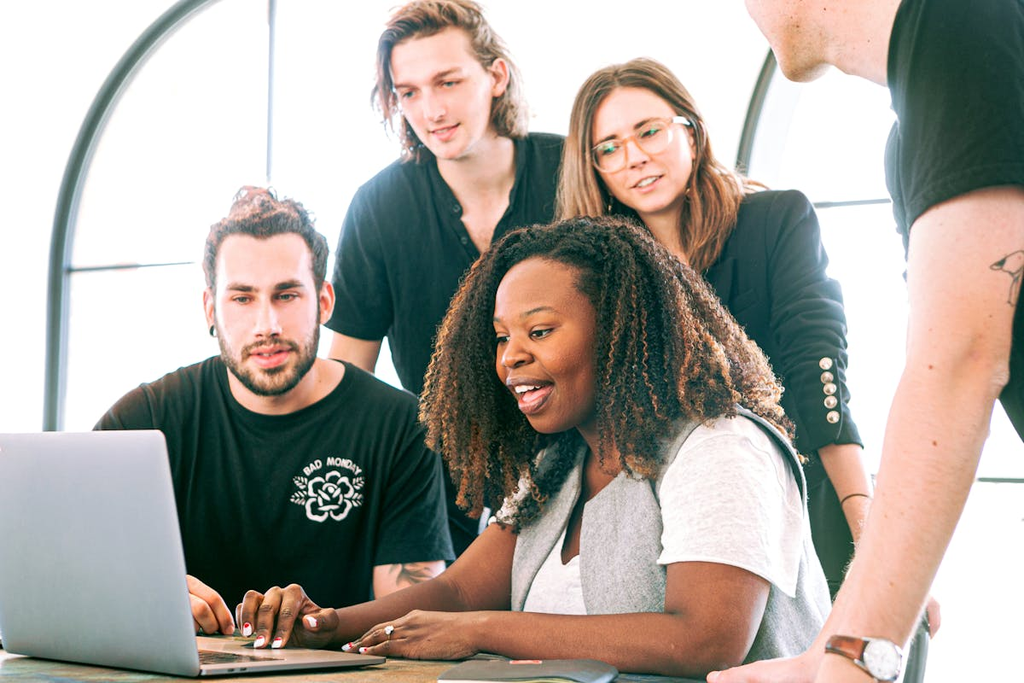

## Síntese: Valoração e Comercialização de PI

### Natureza Estratégica

**Integração Multidisciplinar** - Teoria econômica - Análise de mercado - Conhecimento jurídico - Competência técnica

**Processos Interligados** - Valoração informa comercialização - Comercialização valida valoração - Ciclo de aprendizado

### Evolução Metodológica

**Clássica** (Smith & Parr, 2000) - Custo, Mercado, Renda

⬇️

**Probabilística** - Monte Carlo, Opções Reais

⬇️

**Computacional** (Zhou & Wang, Wu & Li, 2022) - Machine Learning - Modelos integrados

**Reflexo**: Complexidade crescente dos ativos intangíveis

## Decisão Estratégica Informada

### Escolha de Estratégia de Comercialização

**Modelos** (Bozeman, 2000) - Licenciamento - Joint ventures - Spin-offs

**Indissociável de:**

**Regimes de Apropriabilidade** (Teece, 1986) - Força da proteção - Ativos complementares - Posição competitiva

### Framework de Decisão

**Bradley et al. (2013)** 1. Maturidade tecnológica (TRL) 2. Análise de mercado 3. Estratégia de PI 4. Capacidades organizacionais

**Fator Crítico**: Capacidade Absortiva do parceiro (Cohen & Levinthal, 1990)

**Resultado**: Decisão contextualizada e fundamentada

## Fortalecimento dos NITs no Brasil

### Importância Estratégica

**Marco Legal de CT&I** - Lei 13.243/2016 - Decreto 9.283/2018 - Ampliação de competências

**Papel dos NITs** - Mediadores estratégicos - Gestores de ativos intangíveis - Articuladores de ecossistema

Aplicar conhecimento de forma contextualizada

### Arsenal Necessário

**Metodológico** - Valoração adaptada - Ferramentas avançadas - Inteligência competitiva

**Relacional** - Capacidade de negociação - Articulação institucional - Mediação de interesses

**Objetivo Final**: Converter PI em motor de vantagem competitiva e desenvolvimento

## Articulação: Técnica, Mercado e Estratégia

### Dimensões Integradas

**Técnica** - Métodos rigorosos de valoração - Ferramentas analíticas avançadas - Modelagem de incerteza

**Mercado** - Análise de demanda e concorrência - Identificação de oportunidades - Timing estratégico

**Estratégia** - Escolha de modelo de comercialização - Gestão de ativos complementares - Construção de capacidades

**Essência**

“Bem articular técnica, mercado e estratégia”

**Transformação**

Ativos Intangíveis ⬇️ Retornos Econômicos ⬇️ Posicionamento Competitivo ⬇️ Desenvolvimento Nacional

## Referências

**Arora et al.** Markets for Technology: The Economics of Innovation and Corporate Strategy, 2001.

**Bozeman** Technology transfer and public policy: a review of research and theory, 2000.

**Bradley et al.** Models and methods of university technology transfer, 2013.

**Brasil** Lei nº 13.243, de 11 de janeiro de 2016 (Marco Legal de CT&I), 2016.

**Brasil** Decreto nº 9.283, de 7 de fevereiro de 2018, 2018.

**Cohen e Levinthal** Absorptive Capacity: A New Perspective on Learning and Innovation, 1990.

**Embrapa** Valoração de ativos tecnológicos: metodologias, aplicações e desafios no setor público, 2022.

**ICC Brasil** Manual de Avaliação de Ativos de Propriedade Intelectual, 2022.

**Lev** Intangibles: Management, Measurement, and Reporting, 2001.

**Smith e Parr** Valuation of Intellectual Property and Intangible Assets, 2000.

**Teece** Profiting from technological innovation: implications for integration, collaboration, licensing and public policy, 1986.

**Wu e Li** Research on technology contribution evaluation model for commercialization, 2022.

**Zhou e Wang** Measuring intangible assets using parametric and machine learning approaches, 2022.

**Obrigado!**

**Luiz Diego Vidal Santos**

Universidade Federal de Sergipe

ldvsantos@uefs.br